# email-exploratory-data-analysis

shobha mourya

March 3, 2019

# 1 Exploratory Data Analysis of email dataset

EDA (exploratory data analysis) in exploring a new dataset

- the email data set contains information on all the emails received by a single email account in a single month
- each email is a case
- the email dataset has 3921 emails from a single account in a month

## 1.1 Data Analysis Objective

Understand what each of the variables mean from the help file

- one of your guiding questions throughout the chapter is - what characteristics of an email are associated with it being spam or not-spam

## 1.2 Summaries

Numerical and graphical summaries are a great way to start answering that question

## 1.3 Graphical Tools

Let’s review the main graphical tools that we have for numerical data

### 1.3.1 Histograms

1. take continuous data and aggregate it into bins then draw a bar to the height that corresponds to the number of cases in that bin
2. they have a tuning parameter that you should play with, the binwidth, to explore the shape of the distribution at different scales
3. if you are interested in building histograms broken down based on a categorical variable they are good candidate for faceting, which can be done with the facet wrap layer

**ggplot(data, aes(x = var1)) + geom_histogram() + facet_wrap(~var2)**

### 1.3.2 Boxplots

1. excel at comparing multiple distributions
2. ggplot requires that you put something on the x-axis
3. if var2 of x-axis has two levels you will get two side-by-side boxplots
4. the boxplot uses robust measures, the median and the IQR, to draw the box and it also flags potential outliers for you
5. the downside however is that it can hide more complicated shapes such as the bimodal distribution
6. to get a single boxplot you just map x to number 1

**ggplot(data, aes(x = var2, y = var1)) + geom_boxplot()**

### 1.3.3 Density plots

1. summarize the data by drawing a smooth line to represent its shape
2. similar to histograms, you can change the smoothness of the graph by changing the biwidth parameter
3. which you can then add to the geom_density function
4. these can be faceted just like histograms or they can be overlaid on one another by mapping the colour of fill of the distribution to a second variable
5. if you want the colour to be somewhat transparent specify an alpha parameter between 0 and 1

**ggplot((data, aes(x = var)) + geom_density()**

Load the R libraries

```r
library(readr)
```

```r
library(ggplot2)
library(dplyr)
library(openintro)
# email dataset in openintro
str(email)
```

```
## 'data.frame':    3921 obs. of  21 variables:
##  $ spam        : num  0 0 0 0 0 0 0 0 0 0 ...
##  $ to_multiple : num  0 0 0 0 0 0 1 1 0 0 ...
##  $ from        : num  1 1 1 1 1 1 1 1 1 1 ...
##  $ cc          : int  0 0 0 0 0 0 0 1 0 0 ...
##  $ sent_email  : num  0 0 0 0 0 0 1 1 0 0 ...
##  $ time        : POSIXct, format: "2012-01-01 11:46:41" "2012-01-01 12:33:59" ...
##  $ image       : num  0 0 0 0 0 0 0 1 0 0 ...
##  $ attach      : num  0 0 0 0 0 0 0 1 0 0 ...
##  $ dollar      : num  0 0 4 0 0 0 0 0 0 0 ...
##  $ winner      : Factor w/ 2 levels "no","yes": 1 1 1 1 1 1 1 1 1 1 ...
##  $ inherit     : num  0 0 1 0 0 0 0 0 0 0 ...
##  $ viagra      : num  0 0 0 0 0 0 0 0 0 0 ...
##  $ password    : num  0 0 0 0 2 2 0 0 0 0 ...
##  $ num_char    : num  11.37 10.5 7.77 13.26 1.23 ...
##  $ line_breaks : int  202 202 192 255 29 25 193 237 69 68 ...
##  $ format      : num  1 1 1 1 0 0 1 1 0 1 ...
##  $ re_subj     : num  0 0 0 0 0 0 0 0 0 0 ...
##  $ exclaim_subj: num  0 0 0 0 0 0 0 0 0 0 ...
##  $ urgent_subj : num  0 0 0 0 0 0 0 0 0 0 ...
##  $ exclaim_mess: num  0 1 6 48 1 1 1 18 1 0 ...
##  $ number      : Factor w/ 3 levels "none","small",..: 3 2 2 2 1 1 3 2 2 2 ...
```

```r
glimpse(email)
```

```
## Observations: 3,921
## Variables: 21
## $ spam         <dbl> 0, 0, 0, 0, 0, 0, 0, 0, 0, 0, 0, 0, 0, 0, 0, 0, 0...
## $ to_multiple  <dbl> 0, 0, 0, 0, 0, 0, 1, 1, 0, 0, 0, 0, 0, 0, 0, 0, 0...
## $ from         <dbl> 1, 1, 1, 1, 1, 1, 1, 1, 1, 1, 1, 1, 1, 1, 1, 1, 1...
## $ cc           <int> 0, 0, 0, 0, 0, 0, 0, 1, 0, 0, 0, 1, 0, 1, 2, 1, 0...
## $ sent_email   <dbl> 0, 0, 0, 0, 0, 0, 1, 1, 0, 0, 1, 0, 0, 1, 0, 1, 0...
## $ time         <dttm> 2012-01-01 11:46:41, 2012-01-01 12:33:59, 2012-0...
## $ image        <dbl> 0, 0, 0, 0, 0, 0, 0, 1, 0, 0, 0, 0, 0, 0, 0, 0, 0...
## $ attach       <dbl> 0, 0, 0, 0, 0, 0, 0, 1, 0, 0, 0, 0, 0, 0, 0, 0, 0...
## $ dollar       <dbl> 0, 0, 4, 0, 0, 0, 0, 0, 0, 0, 0, 0, 0, 0, 2, 0, 5...
## $ winner       <fct> no, no, no, no, no, no, no, no, no, no, no, no, n...
## $ inherit      <dbl> 0, 0, 1, 0, 0, 0, 0, 0, 0, 0, 0, 0, 0, 0, 0, 0, 0...
## $ viagra       <dbl> 0, 0, 0, 0, 0, 0, 0, 0, 0, 0, 0, 0, 0, 0, 0, 0, 0...
## $ password     <dbl> 0, 0, 0, 0, 2, 2, 0, 0, 0, 0, 0, 0, 0, 0, 0, 0, 1...
## $ num_char     <dbl> 11.370, 10.504, 7.773, 13.256, 1.231, 1.091, 4.83...
## $ line_breaks  <int> 202, 202, 192, 255, 29, 25, 193, 237, 69, 68, 25,...
## $ format       <dbl> 1, 1, 1, 1, 0, 0, 1, 1, 0, 1, 1, 0, 1, 1, 1, 1, 1...
## $ re_subj      <dbl> 0, 0, 0, 0, 0, 0, 0, 0, 0, 0, 0, 1, 0, 1, 1, 1, 0...
## $ exclaim_subj <dbl> 0, 0, 0, 0, 0, 0, 0, 0, 0, 0, 0, 0, 0, 0, 0, 0, 1...
## $ urgent_subj  <dbl> 0, 0, 0, 0, 0, 0, 0, 0, 0, 0, 0, 0, 0, 0, 0, 0, 0...
## $ exclaim_mess <dbl> 0, 1, 6, 48, 1, 1, 1, 18, 1, 0, 2, 1, 0, 10, 4, 1...
## $ number       <fct> big, small, small, small, none, none, big, small,...
```

## 1.4 Variables

**spam and num_char** Is there an association between spam and the length of an email? You could imagine a story either way: Spam is more likely to be a short message tempting me to click on alink, or My normal email is likely shorter since I exchange brief emails with my friends all the time

Here, you’ll use the email dataset to settle that question.

Begin by bringing up the help file and learning about all the variables with

```r
?email
```

**Description**

These data represent incoming emails for the first three months of 2012 for an email account (see Source).

Usage

data(email) data(email_test) Format

A email (email_sent) data frame has 3921 (1252) observations on the following 21 variables.

### 1.4.1 spam

Indicator for whether the email was spam.

### 1.4.2 to_multiple

Indicator for whether the email was addressed to more than one recipient.

### 1.4.3 from

Whether the message was listed as from anyone (this is usually set by default for regular outgoing email).

### 1.4.4 cc

Indicator for whether anyone was CCed.

### 1.4.5 sent_email

Indicator for whether the sender had been sent an email in the last 30 days.

### 1.4.6 time

Time at which email was sent.

### 1.4.7 image

The number of images attached.

### 1.4.8 attach

The number of attached files.

### 1.4.9 dollar

The number of times a dollar sign or the word “dollar” appeared in the email.

### 1.4.10 winner

Indicates whether “winner” appeared in the email.

### 1.4.11 inherit

The number of times “inherit” (or an extension, such as “inheritance”) appeared in the email.

### 1.4.12 viagra

The number of times “viagra” appeared in the email.

### 1.4.13 password

The number of times “password” appeared in the email.

### 1.4.14 num_char

The number of characters in the email, in thousands.

### 1.4.15 line_breaks

The number of line breaks in the email (does not count text wrapping).

### 1.4.16 format

Indicates whether the email was written using HTML (e.g. may have included bolding or active links).

### 1.4.17 re_subj

Whether the subject started with “Re:”, “RE:”, “re:”, or “rE:”

### 1.4.18 exclaim_subj

Whether there was an exclamation point in the subject.

### 1.4.19 urgent_subj

Whether the word “urgent” was in the email subject.

### 1.4.20 exclaim_mess

The number of exclamation points in the email message.

### 1.4.21 number

Factor variable saying whether there was no number, a small number (under 1 million), or a big number.

As you explore the association between spam and the length of an email, use this opportunity to try out linking a dplyr chain with the layers in a ggplot2 object

# 2 Proportion of spam vs not-spam

```r
names(email)
```

```
##  [1] "spam"         "to_multiple"  "from"         "cc"
##  [5] "sent_email"   "time"         "image"        "attach"
##  [9] "dollar"       "winner"       "inherit"      "viagra"
## [13] "password"     "num_char"     "line_breaks"  "format"
## [17] "re_subj"      "exclaim_subj" "urgent_subj"  "exclaim_mess"
## [21] "number"
```

```r
glimpse(email)
```

```
## Observations: 3,921
## Variables: 21
## $ spam         <dbl> 0, 0, 0, 0, 0, 0, 0, 0, 0, 0, 0, 0, 0, 0, 0, 0, 0...
## $ to_multiple  <dbl> 0, 0, 0, 0, 0, 0, 1, 1, 0, 0, 0, 0, 0, 0, 0, 0, 0...
## $ from         <dbl> 1, 1, 1, 1, 1, 1, 1, 1, 1, 1, 1, 1, 1, 1, 1, 1, 1...
## $ cc           <int> 0, 0, 0, 0, 0, 0, 0, 1, 0, 0, 0, 1, 0, 1, 2, 1, 0...
## $ sent_email   <dbl> 0, 0, 0, 0, 0, 0, 1, 1, 0, 0, 1, 0, 0, 1, 0, 1, 0...
## $ time         <dttm> 2012-01-01 11:46:41, 2012-01-01 12:33:59, 2012-0...
## $ image        <dbl> 0, 0, 0, 0, 0, 0, 0, 1, 0, 0, 0, 0, 0, 0, 0, 0, 0...
## $ attach       <dbl> 0, 0, 0, 0, 0, 0, 0, 1, 0, 0, 0, 0, 0, 0, 0, 0, 0...
## $ dollar       <dbl> 0, 0, 4, 0, 0, 0, 0, 0, 0, 0, 0, 0, 0, 0, 2, 0, 5...
## $ winner       <fct> no, no, no, no, no, no, no, no, no, no, no, no, n...
## $ inherit      <dbl> 0, 0, 1, 0, 0, 0, 0, 0, 0, 0, 0, 0, 0, 0, 0, 0, 0...
## $ viagra       <dbl> 0, 0, 0, 0, 0, 0, 0, 0, 0, 0, 0, 0, 0, 0, 0, 0, 0...
## $ password     <dbl> 0, 0, 0, 0, 2, 2, 0, 0, 0, 0, 0, 0, 0, 0, 0, 0, 1...
## $ num_char     <dbl> 11.370, 10.504, 7.773, 13.256, 1.231, 1.091, 4.83...
## $ line_breaks  <int> 202, 202, 192, 255, 29, 25, 193, 237, 69, 68, 25,...
## $ format       <dbl> 1, 1, 1, 1, 0, 0, 1, 1, 0, 1, 1, 0, 1, 1, 1, 1, 1...
## $ re_subj      <dbl> 0, 0, 0, 0, 0, 0, 0, 0, 0, 0, 0, 1, 0, 1, 1, 1, 0...
## $ exclaim_subj <dbl> 0, 0, 0, 0, 0, 0, 0, 0, 0, 0, 0, 0, 0, 0, 0, 0, 1...
## $ urgent_subj  <dbl> 0, 0, 0, 0, 0, 0, 0, 0, 0, 0, 0, 0, 0, 0, 0, 0, 0...
## $ exclaim_mess <dbl> 0, 1, 6, 48, 1, 1, 1, 18, 1, 0, 2, 1, 0, 10, 4, 1...
## $ number       <fct> big, small, small, small, none, none, big, small,...
```

```r
table(email$spam)
```

```
##
##    0    1
## 3554  367
```

```r
prop.table(table(email$spam))*100
```

```
##
##         0         1
## 90.640143  9.359857
```

**only 9% emails were spam**

## 2.1 Explore num_char feature

```r
str(email$num_char)
```

```
##  num [1:3921] 11.37 10.5 7.77 13.26 1.23 ...
```

```r
summary(email$num_char)
```

```
##    Min. 1st Qu.  Median    Mean 3rd Qu.    Max.
##   0.001   1.459   5.856  10.707  14.084 190.087
```

```r
nrow(email)
```

```
## [1] 3921
```

```r
# Start by exploring num_char feature
str(email$num_char)
```

```
##  num [1:3921] 11.37 10.5 7.77 13.26 1.23 ...
```

```r
summary(email$num_char)
```

```
##    Min. 1st Qu.  Median    Mean 3rd Qu.    Max.
##   0.001   1.459   5.856  10.707  14.084 190.087
```

**Unit is in thousands**

**Visualizations for numeric variable num_char**

Compute appropriate measures of the center and spread of num_char for both spam and non-spam using group_by() and summarize(). No need to name the new columns created by summarize()

### 2.1.1 Boxplot

Boxplot for numeric variable num_char, y-axis has the measures of center and spread and x-axis is set to 1 as we’re not plotting multiple boxplots for num_char based on a particular categorical variable.

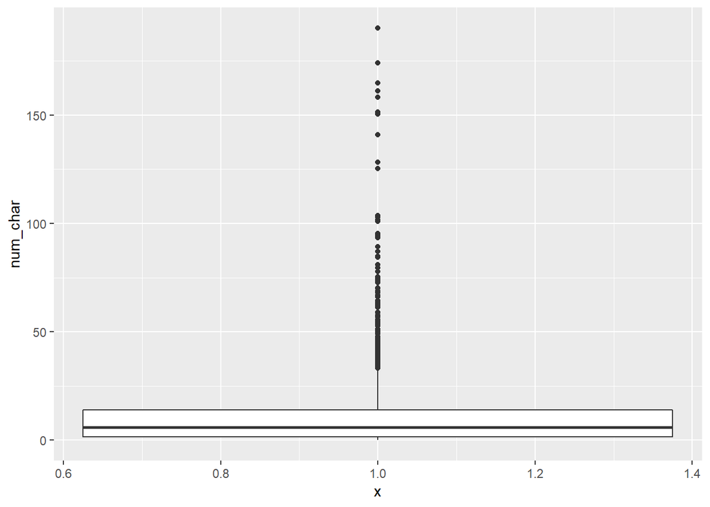

```r
email %>%
  ggplot(aes(x=1, y = num_char)) +
  geom_boxplot()
```

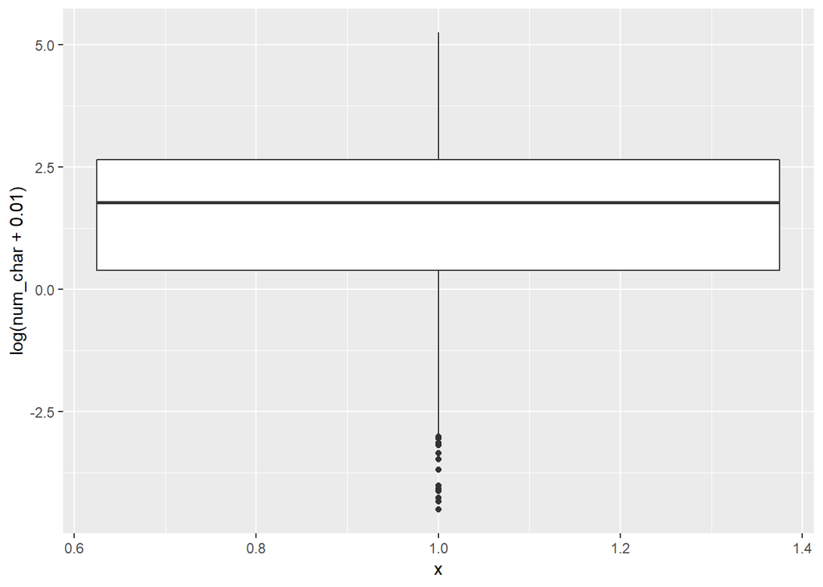

```r
# Boxplot show many outliers, so taking log of num_char

email %>%
  ggplot(aes(x=1, y = log(num_char + 0.01))) +
  geom_boxplot()
```

Boxplot also shows many outliers on the lower side, so there are extreme values at the left and mean,sd will be affected by these extreme values. Let’s check with density plot

### 2.1.2 Density Plot

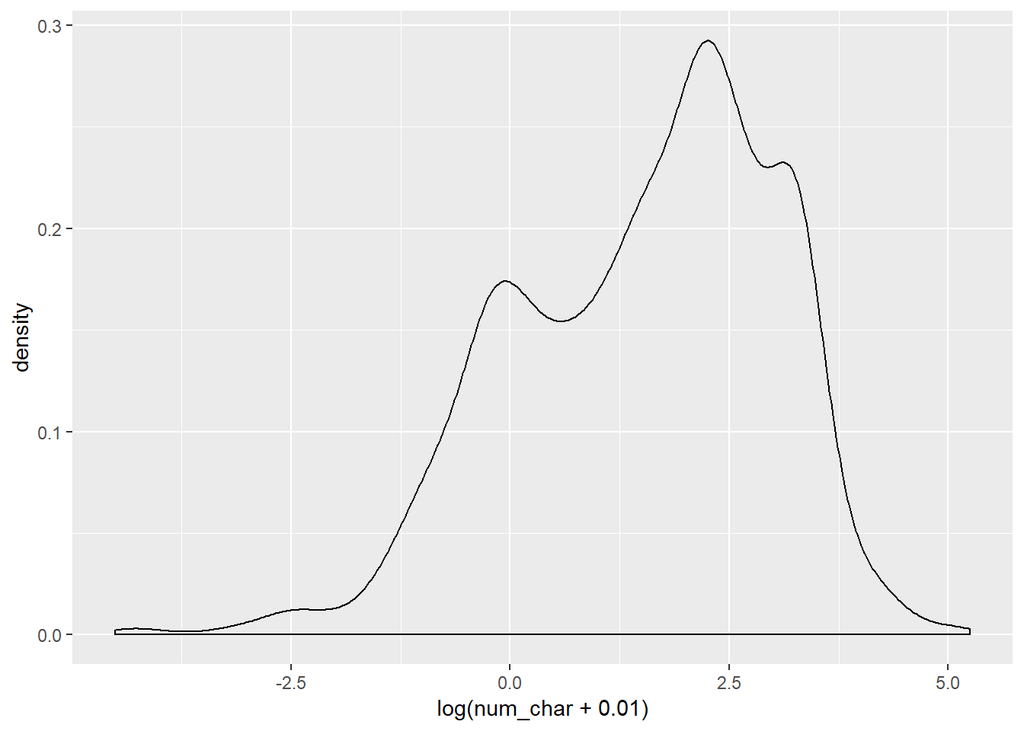

```r
email %>% ggplot(aes(x = log(num_char + 0.01))) +
  geom_density()
```

The density plot shows there are more than one peaks, bimodal distribution and there are extremed values so let’s use median and IQR

### 2.1.3 Measures of Center and Spread

**median and IQR for spam and non-spam messages**

```r
email %>%
  group_by(spam) %>%
  summarise(median(num_char), IQR(num_char))
```

```
## # A tibble: 2 x 3
##    spam `median(num_char)` `IQR(num_char)`
##   <dbl>              <dbl>           <dbl>
## 1     0               6.83           13.6
## 2     1               1.05            2.82
```

**It appears spam messages are shorter than ham messages**

### 2.1.4 Side-by-side boxplot for spam and not-spam wrt num_char

Construct side-by-side box plots to visualize the association between the same two variables. It will be useful to mutate() a new column containing a log-transformed version of num_char.

```r
email = email %>%
  mutate(log_num_char = log(num_char + 0.01))

names(email)
```

```
##  [1] "spam"         "to_multiple"  "from"         "cc"
##  [5] "sent_email"   "time"         "image"        "attach"
##  [9] "dollar"       "winner"       "inherit"      "viagra"
## [13] "password"     "num_char"     "line_breaks"  "format"
## [17] "re_subj"      "exclaim_subj" "urgent_subj"  "exclaim_mess"
## [21] "number"       "log_num_char"
```

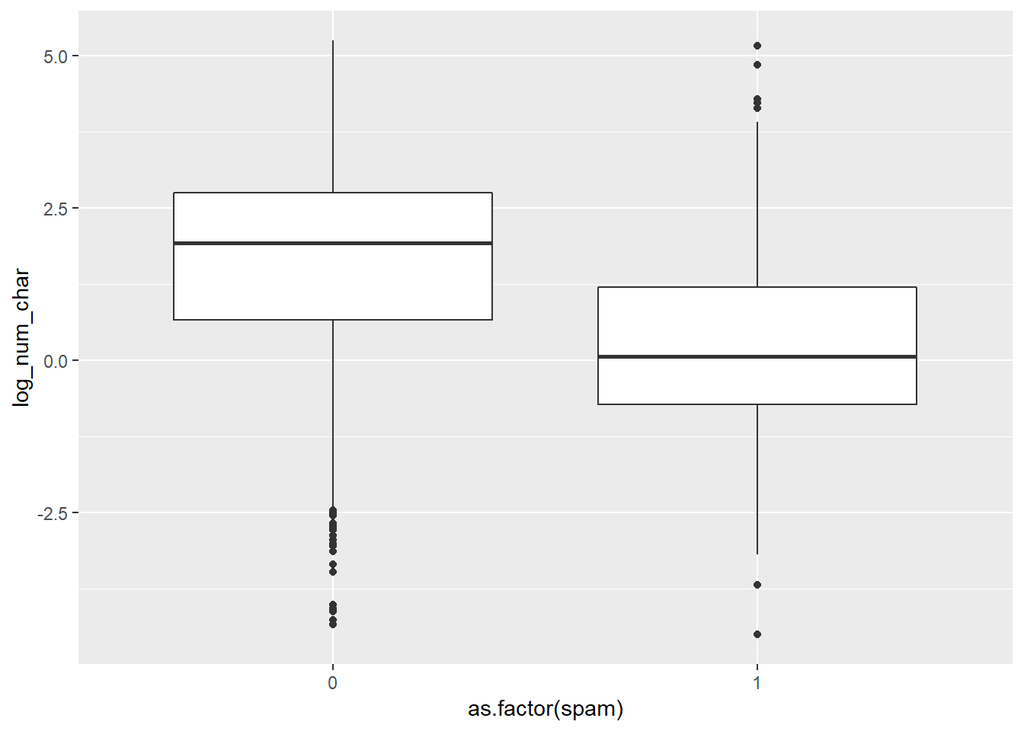

```r
# boxplot for num_char based on spam or not

ggplot(email, aes(x = as.factor(spam), y = log_num_char)) +
  geom_boxplot()
```

### 2.1.5 Interpretation

The boxplot shows that median length of not-spam emails is greater than that of spam emails

## 2.2 Explore exclaim_ness feature

Lets look at a more obvious indicator of spam: exclamation marks * exclaim_mess contains the number of exclamation marks in each message * using summary statistics and visualization, see if there is a relationship between this variable and whether or not a message is spam

Experiment with different types of plots until you find one that is the most informative.

Recall that you’ve seen:

- side-by-side box plots
- faceted histograms
- overlaid density plots

```r
names(email)
```

```
##  [1] "spam"         "to_multiple"  "from"         "cc"
##  [5] "sent_email"   "time"         "image"        "attach"
##  [9] "dollar"       "winner"       "inherit"      "viagra"
## [13] "password"     "num_char"     "line_breaks"  "format"
## [17] "re_subj"      "exclaim_subj" "urgent_subj"  "exclaim_mess"
## [21] "number"       "log_num_char"
```

```r
str(email$exclaim_mess)
```

```
##  num [1:3921] 0 1 6 48 1 1 1 18 1 0 ...
```

```r
summary(email$exclaim_mess)
```

```
##     Min.  1st Qu.   Median     Mean  3rd Qu.     Max.
##    0.000    0.000    1.000    6.584    4.000 1236.000
```

### 2.2.1 Overlaid density plot

Construct an appropriate plot to visualize the association between the same two variables, adding in a log-transformation step if necessary.

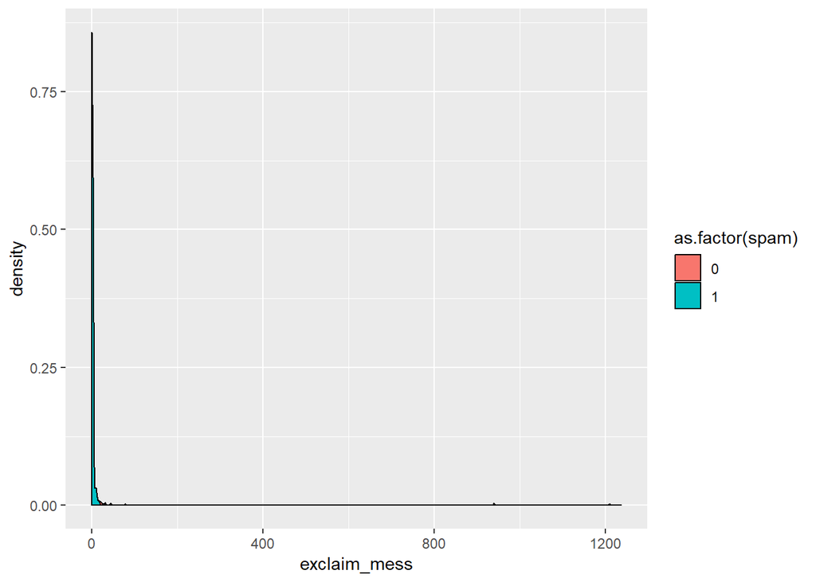

```r
# overlaid density plot
email %>% ggplot(aes(x = exclaim_mess, fill = as.factor(spam))) +
  geom_density()
```

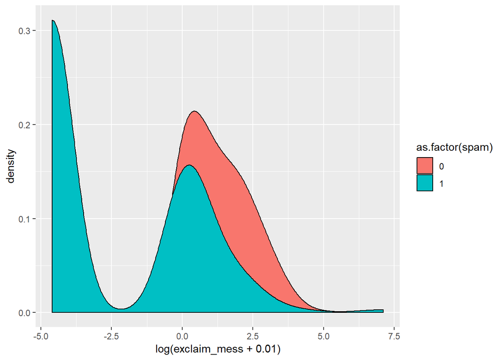

```r
# Since the plot is not clear, use the log transformed values
email %>% ggplot(aes(x = log(exclaim_mess + 0.01), fill = as.factor(spam))) +
  geom_density()
```

### 2.2.2 log(0) correction

log(0) is -Inf and these values get ignored. If you decide to use a log transformation, remember that log(0) is -Inf in R, which isn’t a very useful value! You can get around this by adding a small number (like .01) to the quantity inside the log() function. This way, your value is never zero. This small shift to the right won’t affect your results.

Let’s create a new variable for log transformed values

```r
# creating a log transformed variable for exclaim_mess
email = email %>%
  mutate(log_exclaim_mess = log(exclaim_mess + 0.01))

names(email)
```

```
##  [1] "spam"             "to_multiple"      "from"
##  [4] "cc"               "sent_email"       "time"
##  [7] "image"            "attach"           "dollar"
## [10] "winner"           "inherit"          "viagra"
## [13] "password"         "num_char"         "line_breaks"
## [16] "format"           "re_subj"          "exclaim_subj"
## [19] "urgent_subj"      "exclaim_mess"     "number"
## [22] "log_num_char"     "log_exclaim_mess"
```

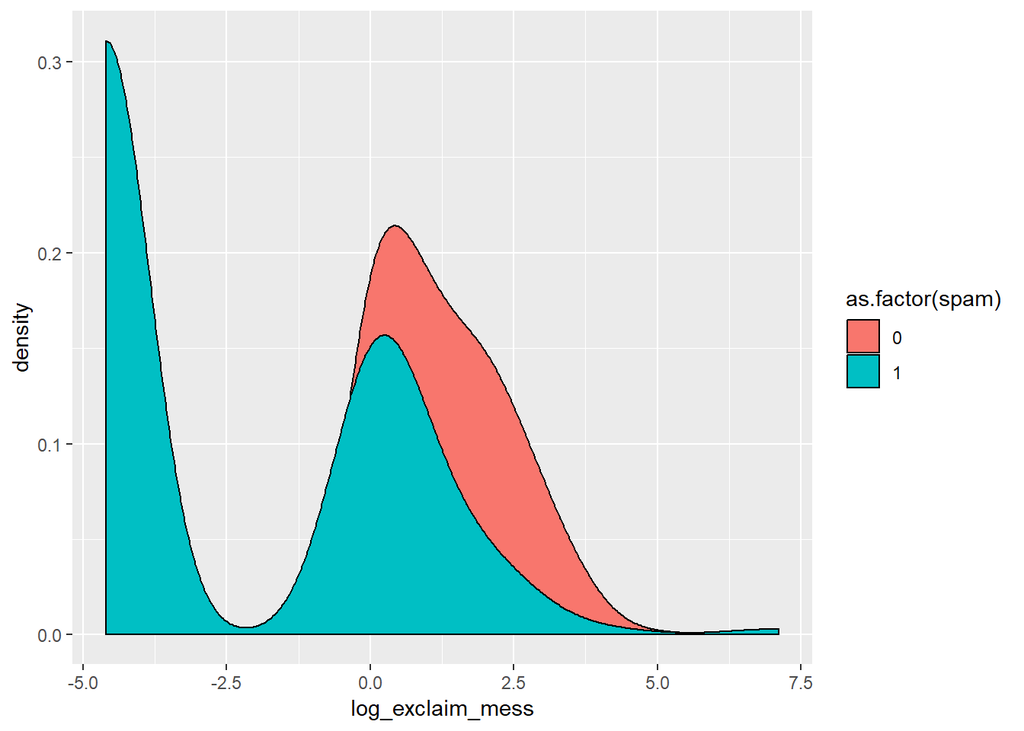

```r
# use the new log transformed variable
email %>%
  ggplot(aes(x = log_exclaim_mess, fill = as.factor(spam))) +
  geom_density()
```

### 2.2.3 Histogram

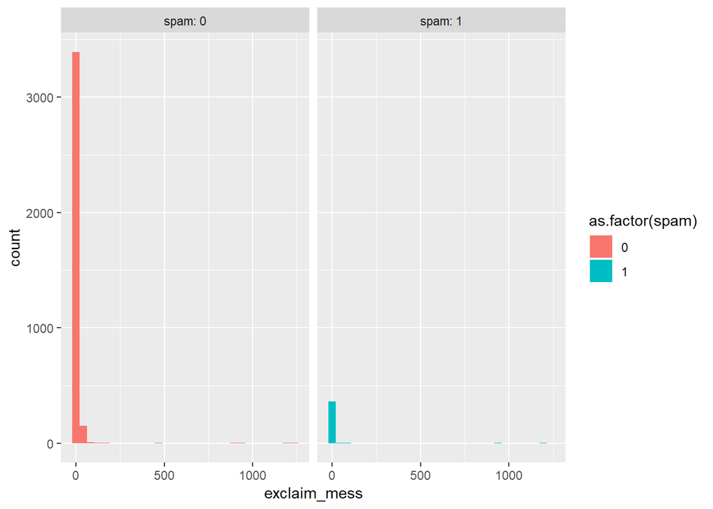

```r
# histogram
email %>%
  ggplot(aes(x = exclaim_mess, fill = as.factor(spam))) +
  geom_histogram() +
  facet_wrap(~spam, labeller = label_both)
```

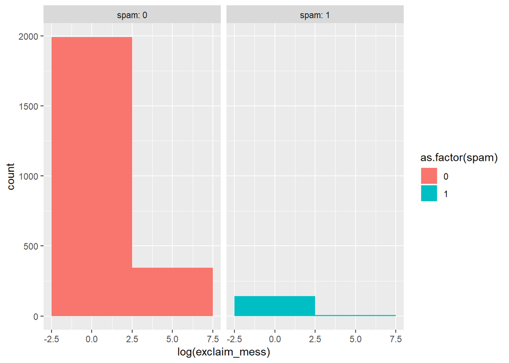

```r
# Since the plot is not clear, use the log transformed values
email %>% ggplot(aes(x = log(exclaim_mess), fill = as.factor(spam))) +
  geom_histogram(binwidth = 5) +
  facet_wrap(~spam, labeller = label_both)
```

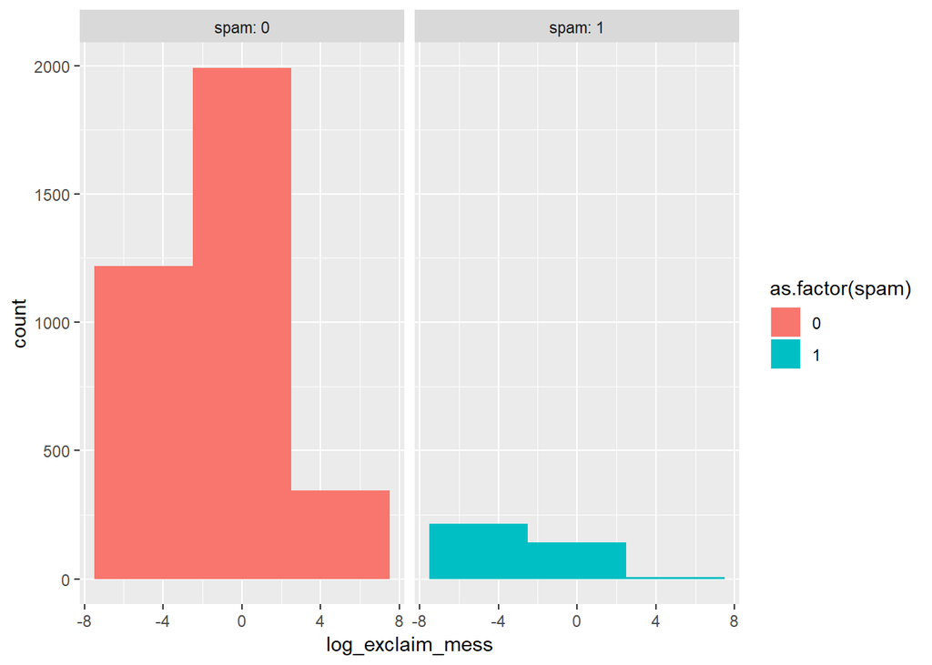

```r
# since we're losing many rows, let's use log_exclaim_mess which
# avoild -Inf values for log(0) by adding 0.01 to exclaim_mess values

email %>% ggplot(aes(x = log_exclaim_mess, fill = as.factor(spam))) +
  geom_histogram(binwidth = 5) +
  facet_wrap(~spam,labeller = label_both)
```

### 2.2.4 Boxplot

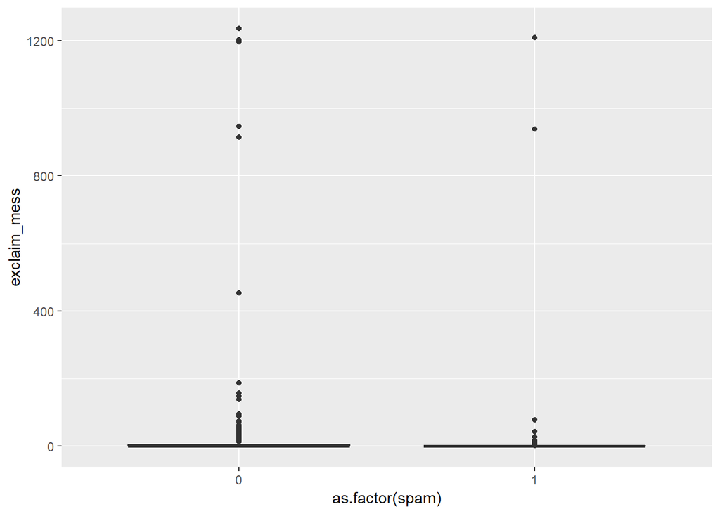

```r
# boxplot
email %>% ggplot(aes(x = as.factor(spam), y = exclaim_mess )) +
  geom_boxplot()
```

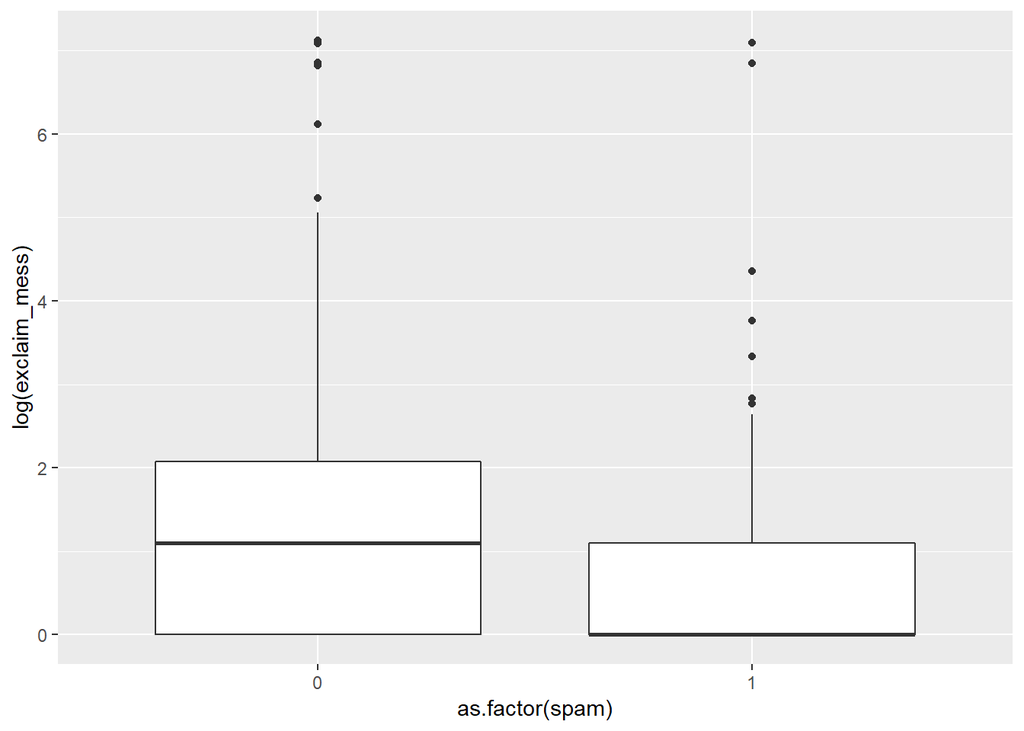

```r
# Since the plot is not clear, use the log transformed values
email %>% ggplot(aes(x = as.factor(spam), y = log(exclaim_mess) )) +
  geom_boxplot()
```

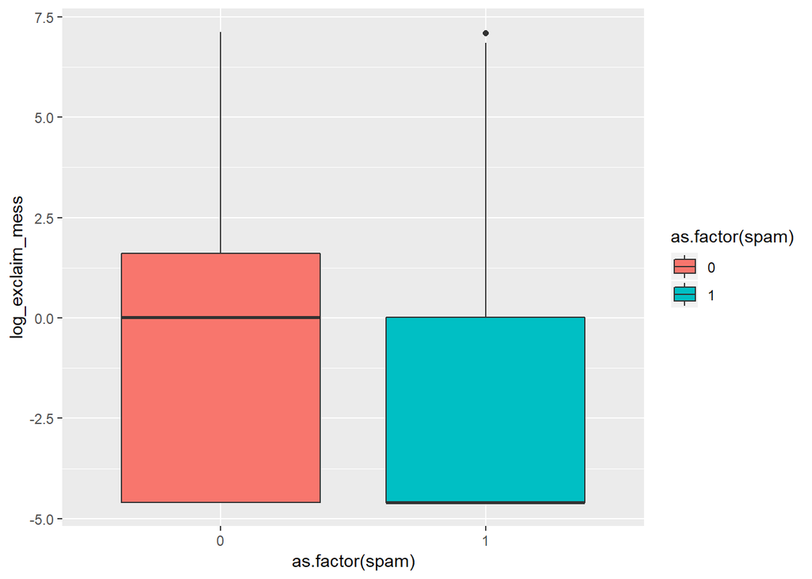

```r
# since we're losing many rows, let's use log_exclaim_mess which
# avoild -Inf values for log(0) by adding 0.01 to exclaim_mess values
email %>% ggplot(aes(x = as.factor(spam),
                     y = log_exclaim_mess,
                     fill = as.factor(spam))) +
  geom_boxplot()
```

### 2.2.5 side-by-side boxplot exclaim_ness for spam and not-spam

Calculate appropriate measures of the center and spread of exclaim_mess for both spam and not-spam using group_by() and summarize()

Observations: The density plot shows that the distribution for exclaim_mess is bimodal - two peaks for spam and one peak for not-spam

Histogram shows exclaim count lower for spams

```r
email %>%
  group_by(spam) %>%
  summarise(mean(exclaim_mess), sd(exclaim_mess))
```

```
## # A tibble: 2 x 3
##    spam `mean(exclaim_mess)` `sd(exclaim_mess)`
##   <dbl>                <dbl>              <dbl>
## 1     0                 6.51               47.6
## 2     1                 7.32               79.9
```

```r
# Final solution:

# Compute center and spread for exclaim_mess by spam
email %>%
  group_by(spam) %>%
  summarise(mean(exclaim_mess), sd(exclaim_mess))
```

```
## # A tibble: 2 x 3
##    spam `mean(exclaim_mess)` `sd(exclaim_mess)`
##   <dbl>                <dbl>              <dbl>
## 1     0                 6.51               47.6
## 2     1                 7.32               79.9
```

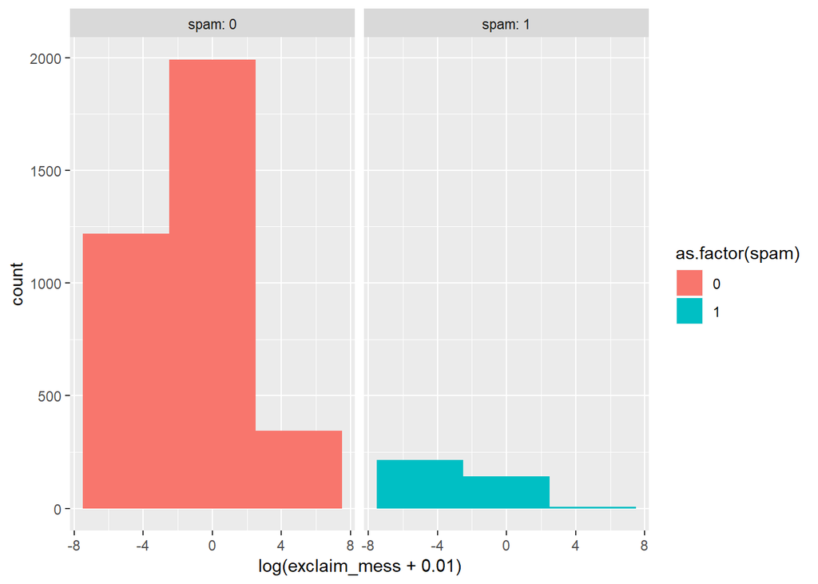

```r
# Create plot for spam and exclaim_mess
email %>% ggplot(aes(x = log(exclaim_mess + 0.01), fill = as.factor(spam))) +
  geom_histogram(binwidth = 5) +
  facet_wrap(~spam, labeller = label_both)
```

### 2.2.6 Spam and !!! interpretation

Which interpretation of these faceted histograms is not correct? { Note not correct! }

The most common value of exclaim_mess in both classes of email is zero (a log(exclaim_mess) of -4.6 after adding .01).

There are more cases of spam in this dataset than not-spam. (Answer)

Even after a transformation, the distribution of exclaim_mess in both classes of email is right-skewed.

The typical number of exclamations in the not-spam group appears to be slightly higher than in the spam group.

### 2.2.7 zero inflation strategies

Let’s review what you learned in last several exercises

- side-by-side boxplots show whether or not an email is spam
- and the length of the emails is measured by log number of characters num_char
- in this case a typical spam message is considerably shorter than the non-spam messages
- but still there is a considerable amount of overlap in the two distributions of length
- when you looked at the distribution of spams and exclamation marks used you saw that both distributions are heavily right-skewed
- there are only a few instances of many exclamation marks being used and many more of 0 or 1 being used
- it also bucks the expectation that spam messages will be filled with emphatic exclamation marks to entice you to click on their links
- here it’s actually not-spam that has more exclamation marks

zero inflation strategies

- the dominant feature of the exclaim_ness feature though is the large proportion of cases that report 0 or -4.6 on the log scale
- this is a common occurence in data analysis that is often termed zero inflation

### 2.2.8 Strategy one

Analyze the two components separately

- and there are several common ways to think about those zeros
- one approach says there are two mechanisms going on
- one generating the zeros and the other generating the non-zeroes
- so we will analyse those two groups separately

### 2.2.9 Strategy two

Collapse into two-level categorical variables One approach is to think of the variable actually taking on only two values zero or not-zero

- and treating it like a categorical variable
- if you take this approach the first step is to mutate this variable
- here our condition is simply that exclaim_ness is zero then we can pipe that new variable into a barchart and facet it based on spam
- in the resulting plot, yes, we have lost a lot of the information but its become very clear that spam is likely to contain no exclamation marks while in spam opposite is true

```r
# Stragegy two - how many zero exclamations and opposite
table(email$exclaim_mess)
```

```
##
##    0    1    2    3    4    5    6    7    8    9   10   11   12   13   14
## 1435  733  507  128  190  113  115   51   93   45   85   17   56   20   43
##   15   16   17   18   19   20   21   22   23   24   25   26   27   28   29
##   11   29   12   26    5   29    9   15    3   11    6   11    1    6    8
##   30   31   32   33   34   35   36   38   39   40   41   42   43   44   45
##   13   12   13    3    3    2    3    3    1    2    1    1    3    3    5
##   46   47   48   49   52   54   55   57   58   62   71   75   78   89   94
##    3    2    1    3    1    1    4    2    2    2    1    1    1    1    1
##   96  139  148  157  187  454  915  939  947 1197 1203 1209 1236
##    1    1    1    1    1    1    1    1    1    1    2    1    1
```

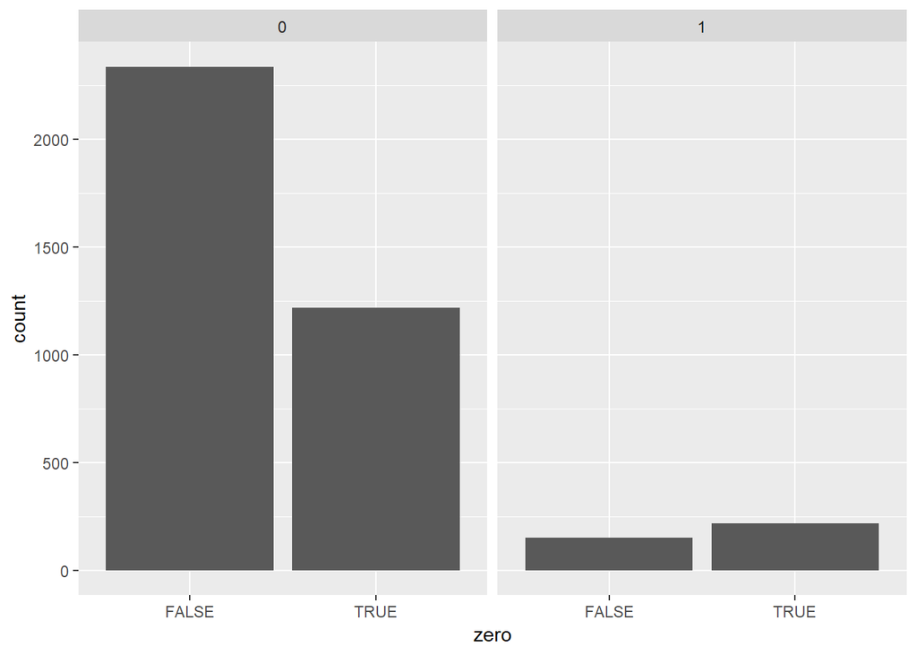

```r
# mutate a categorical variable based on condition that exclaim_mess
# is 0 and plot a barchart facetted by spam
email %>%
  mutate(zero = exclaim_mess == 0) %>%
  ggplot(aes(x = zero)) +
  geom_bar() +
  facet_wrap(~spam)
```

Using stacked barchart - showing the break up in same bar using fill instead of faceted graphs for each label category

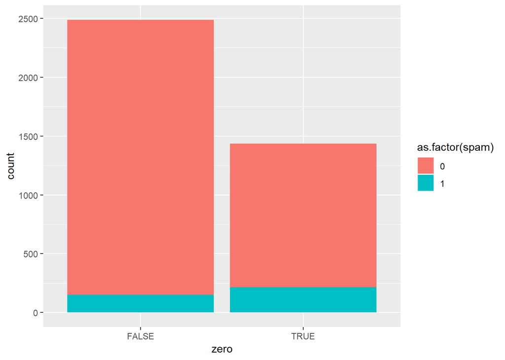

```r
email %>%
  mutate(zero = exclaim_mess == 0) %>%
  ggplot(aes(x = zero, fill = as.factor(spam))) +
  geom_bar()
```

The other consideration is whether you want counts or proportions

- proportions have same bar height
- if the later then you have to normalize the chart which you can do by adding the position = fill argument in geom along with setting it in aes

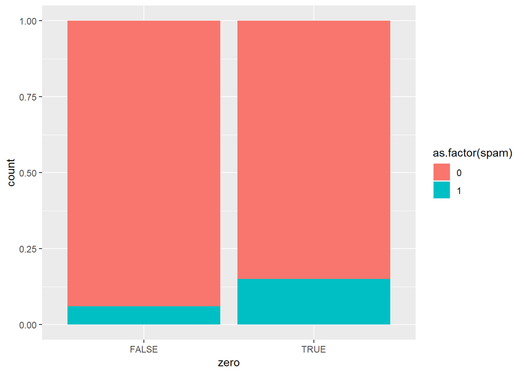

```r
email %>%
  mutate(zero = exclaim_mess == 0) %>%
  ggplot(aes(x = zero, fill = as.factor(spam))) +
  geom_bar(position = "fill")
```

## 2.3 Explore images feature

Collapsing levels

- if it was difficult to work with the heavy skew of exclaim_mess the number of images attached to each email (image) poses even more of a challenge
- Run the following code at the console to get a sense of its distribution

```r
str(email$image)
```

```
##  num [1:3921] 0 0 0 0 0 0 0 1 0 0 ...
```

```r
table(email$image)
```

```
##
##    0    1    2    3    4    5    9   20
## 3811   76   17   11    2    2    1    1
```

```r
summary(email$image)
```

```
##     Min.  1st Qu.   Median     Mean  3rd Qu.     Max.
##  0.00000  0.00000  0.00000  0.04846  0.00000 20.00000
```

There are far more emails without images 3811, maximum with one image is 76 and fewer thereafter.

Given the very low counts at the higher number of images

- let’s collapse image into a categorical variable that indicates whether or not the email had at least one image. In this exercise, you’ll create this new variable and explore its association with spam.

Starting with email, form a continuous chain that links together the following tasks:

Create a new variable has_image that is TRUE where the number of images is greater than zero and FALSE otherwise

Create an appropriate plot with email to visualize the relationship between has_image and spam

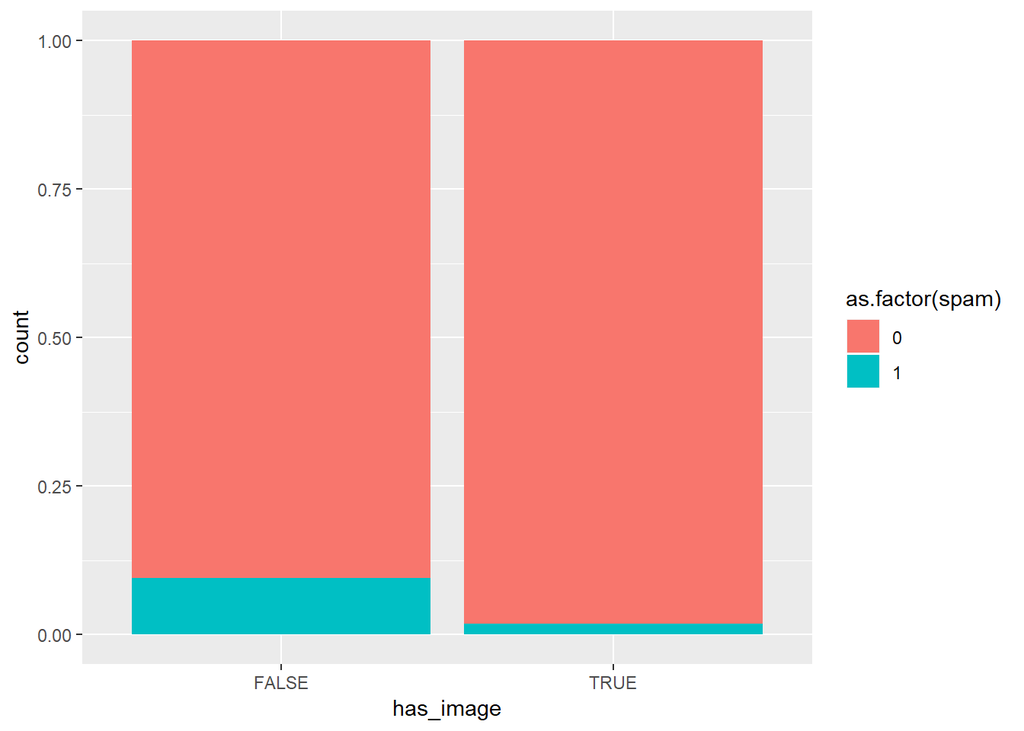

```r
email %>%
  mutate(has_image = image > 0) %>%
  ggplot(aes(x = has_image, fill = as.factor(spam))) +
  geom_bar(position =  "fill")
```

### 2.3.1 Image and spam interpretation:

Which of the following interpretations of the plot is valid?

There are more emails with images than without images.

Emails with images have a higher proportion that are spam than do emails without images.

An email without an image is more likely to be not-spam than spam. (Answer)

Data Integrity In the process of exploring a dataset, you’ll sometimes come across something that will lead you to question how the data were compiled. For example, the variable num_char contains the number of characters in the email, in thousands, so it could take decimal values, but it certainly shouldn’t take negative values.

You can formulate a test to ensure this variable is behaving as we expect:

```r
email$num_char < 0
```

```
##    [1] FALSE FALSE FALSE FALSE FALSE FALSE FALSE FALSE FALSE FALSE FALSE
##   [12] FALSE FALSE FALSE FALSE FALSE FALSE FALSE FALSE FALSE FALSE FALSE
##   [23] FALSE FALSE FALSE FALSE FALSE FALSE FALSE FALSE FALSE FALSE FALSE
##   [34] FALSE FALSE FALSE FALSE FALSE FALSE FALSE FALSE FALSE FALSE FALSE
##   [45] FALSE FALSE FALSE FALSE FALSE FALSE FALSE FALSE FALSE FALSE FALSE
##   [56] FALSE FALSE FALSE FALSE FALSE FALSE FALSE FALSE FALSE FALSE FALSE
##   [67] FALSE FALSE FALSE FALSE FALSE FALSE FALSE FALSE FALSE FALSE FALSE
##   [78] FALSE FALSE FALSE FALSE FALSE FALSE FALSE FALSE FALSE FALSE FALSE
##   [89] FALSE FALSE FALSE FALSE FALSE FALSE FALSE FALSE FALSE FALSE FALSE
##  [100] FALSE FALSE FALSE FALSE FALSE FALSE FALSE FALSE FALSE FALSE FALSE
##  [111] FALSE FALSE FALSE FALSE FALSE FALSE FALSE FALSE FALSE FALSE FALSE
##  [122] FALSE FALSE FALSE FALSE FALSE FALSE FALSE FALSE FALSE FALSE FALSE
##  [133] FALSE FALSE FALSE FALSE FALSE FALSE FALSE FALSE FALSE FALSE FALSE
##  [144] FALSE FALSE FALSE FALSE FALSE FALSE FALSE FALSE FALSE FALSE FALSE
##  [155] FALSE FALSE FALSE FALSE FALSE FALSE FALSE FALSE FALSE FALSE FALSE
```

[output cut: 342 more lines]

If you run this code at the console, you’ll get a long vector of logical values indicating for each case in the dataset whether that condition is TRUE. Here, the first 1000 values all appear to be FALSE. To verify that all of the cases indeed have non-negative values for num_char, we can take the sum of this vector:

```r
sum(email$num_char < 0)
```

```
## [1] 0
```

This is a handy shortcut. When you do arithmetic on logical values, R treats TRUE as 1 and FALSE as 0. Since the sum over the whole vector is zero, you learn that every case in the dataset took a value of FALSE in the test. That is, the num_char column is behaving as we expect and taking only non-negative values.

## 2.4 Explore attach feature

Consider the variables image and attach. You can read about them with ?email, but the help file is ambiguous: do attached images count as attached files in this dataset?

Design a simple test to determine if images count as attached files. This involves creating a logical condition to compare the values of the two variables, then using sum() to assess every case in the dataset. Recall that the logical operators are:

< for less than <= for less than or equal to > for greater than >= for greater than or equal to and == for equal to

```r
unique(email$image)
```

```
## [1]  0  1  2 20  3  5  9  4
```

```r
unique(email$attach)
```

```
##  [1]  0  1  2 20  5  4  3  9 21  7  8  6 10
```

```r
# Test if images count as attachments
"
If image count is greater than attachment, it indicates that image is not counted as attachment.
"
```

```
## [1] " \nIf image count is greater than attachment, it indicates that image is not counted as attachment. \n"
```

```r
sum(email$image > email$attach)
```

```
## [1] 0
```

Since image is never greater than attach, we can infer that images are counted as attachments.

## 2.5 Explore to_multiple feature

Answering questions with chains

When you have a specific question about a dataset

- you can find your way to an answer by carefully constructing the appropriate chain of R code.

For example consider the following question:

- Within non-spam emails, is the typical length of emails shorter for those that were sent to multiple people?

```r
str(email$to_multiple)
```

```
##  num [1:3921] 0 0 0 0 0 0 1 1 0 0 ...
```

```r
unique(email$to_multiple)
```

```
## [1] 0 1
```

```r
# median length of spam messages sent to multiple people
email %>%
  filter(spam == 0) %>%
  group_by(to_multiple) %>%
  summarise(median(num_char))
```

```
## # A tibble: 2 x 2
##   to_multiple `median(num_char)`
##         <dbl>              <dbl>
## 1           0               7.20
## 2           1               5.36
```

Yes - the typical length of non-spam sent to multiple people is a bit lower than those sent to only one person.

This chain concluded with summary statistics, but others might end in a plot; it all depends on the question that you’re trying to answer.

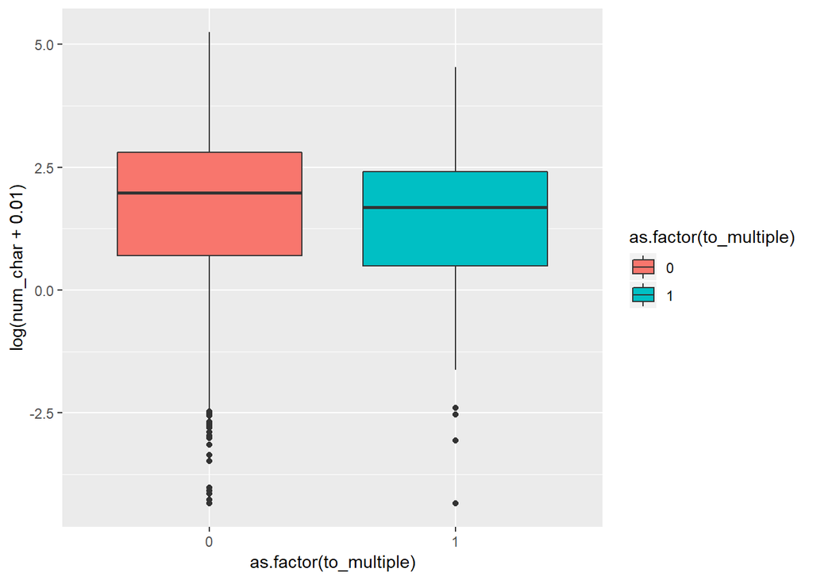

```r
email %>%
  filter(spam == 0) %>%
  ggplot(aes(x = as.factor(to_multiple) ,
             y = log(num_char + 0.01),
             fill = as.factor(to_multiple))) +
  geom_boxplot()
```

## 2.6 Explore dollar feature

Build a chain to answer each of the following questions, both about the variable dollar

For emails containing the word ‘dollar’ does the typical spam email contain a greater number of occurences of the word than the typical non-spam email? Create a summary statistic that answers this question.

```r
head(email$dollar)
```

```
## [1] 0 0 4 0 0 0
```

```r
str(email$dollar)
```

```
##  num [1:3921] 0 0 4 0 0 0 0 0 0 0 ...
```

```r
length(unique(email$dollar))
```

```
## [1] 41
```

```r
summary(email$dollar)
```

```
##    Min. 1st Qu.  Median    Mean 3rd Qu.    Max.
##   0.000   0.000   0.000   1.467   0.000  64.000
```

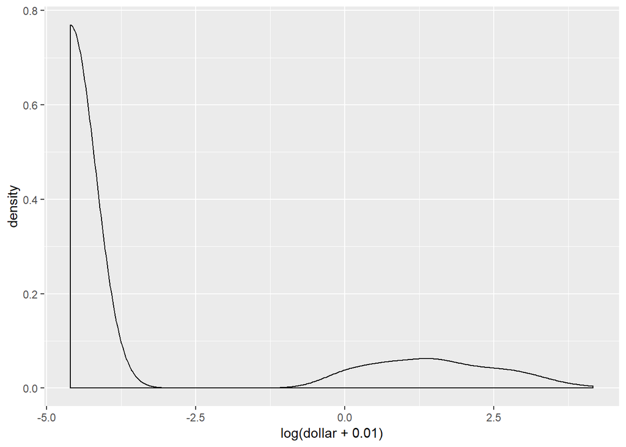

```r
# dollar is numeric so density plot
ggplot(email, aes(x=log(dollar + 0.01))) +
  geom_density()
```

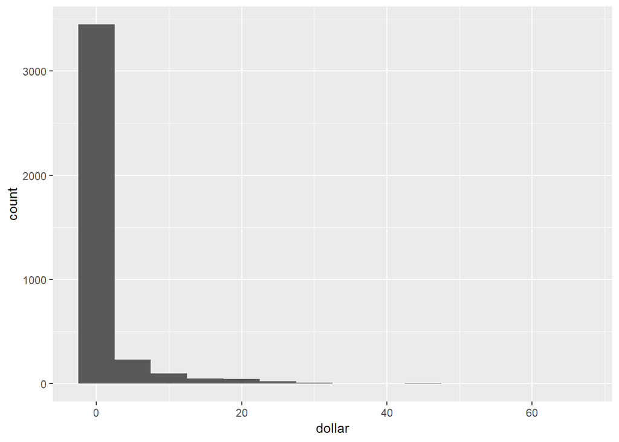

```r
ggplot(email, aes(x= dollar)) +
  geom_histogram(binwidth = 5)
```

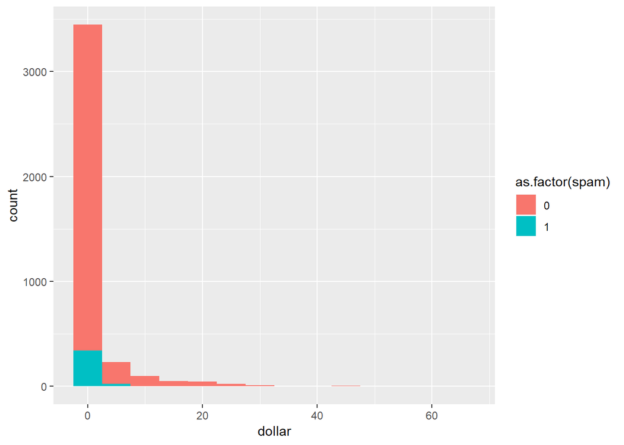

```r
#Clearly there a lot of emails with zero dollar words, lets split by spam
ggplot(email, aes(x= dollar, fill = as.factor(spam))) +
  geom_histogram(binwidth = 5)
```

```r
email %>%
  filter(dollar > 10) %>%
  group_by(spam) %>%
  summarise(n())
```

```
## # A tibble: 2 x 2
##    spam `n()`
##   <dbl> <int>
## 1     0   173
## 2     1     3
```

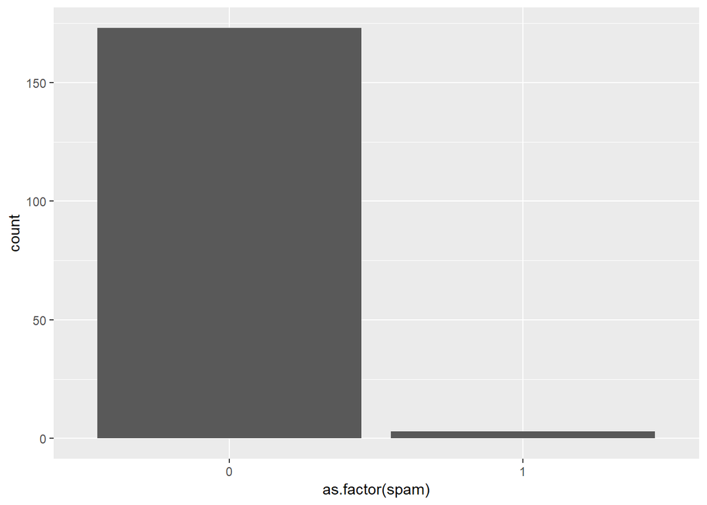

```r
email %>%
  filter(dollar > 10) %>%
  ggplot(aes(x = as.factor(spam))) +
  geom_bar()
```

** So, not-spam emails are more likely to have the dollar word**

Let’s revisit the exercise where you explored the whether an email has an image and whether it is a spam.

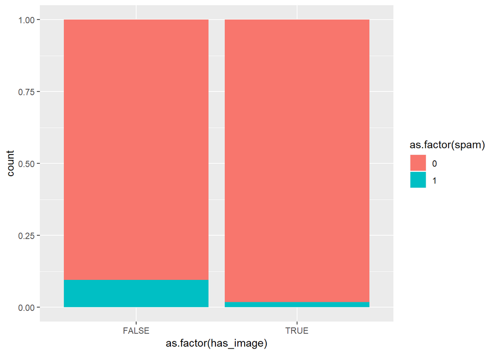

```r
#barchart of proportions
email %>%
  mutate(has_image = image >0) %>%
  ggplot(aes(x = as.factor(has_image), fill = as.factor(spam))) +
  geom_bar(position = "fill")
```

Subtle and important distinction between proportions like the above barchart with proportions for spam or non-spam

- conditioned on has_image variable
- we get a different story if we condition our variable on spam
- amongst the emails that are spam almost none of them have an image

Ordering bars

- to make barcharts readily interpretable
- recall creating variable zero for zero exclamations marks

```r
email = email %>%
  mutate(zero = exclaim_mess == 0)

levels(email$zero)
```

```r
str(email$zero)
```

```
##  logi [1:3921] TRUE FALSE FALSE FALSE FALSE FALSE ...
```

```r
# make zero a factor and set the levels, TRUE first, then FALSE
email$zero = factor(email$zero,
                    levels = c("TRUE", "FALSE"))

levels(email$zero)
```

```
## [1] "TRUE"  "FALSE"
```

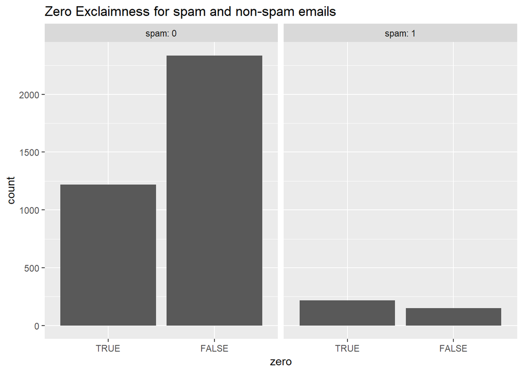

```r
email %>%
  ggplot(aes(x = zero)) +
  geom_bar() +
  facet_wrap(~spam, labeller = label_both)+
  ggtitle("Zero Exclaimness for spam and non-spam emails")
```

## 2.7 Explore number feature

What’s in a number Turn your attention to the variable called number

- read more about it by pullin up the help file ?email

To explore the association between this variable and spam, select and construct an informative plot. For illustrating relationships between categorical variables, you’ve seen

- Faceted barcharts
- Side-by-side barcharts
- Stacked and normalized barcharts

**Let’s practice constructing a faceted barchart**

number variable Factor variable saying whether there was no number, a small number (under 1 million), or a big number.

```r
# Construct a faceted barchart of the associatin between number and spam

str(email$number)
```

```
##  Factor w/ 3 levels "none","small",..: 3 2 2 2 1 1 3 2 2 2 ...
```

```r
table(email$number)
```

```
##
##  none small   big
##   549  2827   545
```

Reorder the levels of number so that they preserve the natural ordering of “none”, then “small”, then “big”.

Construct a faceted barchart of the association between number and spam.

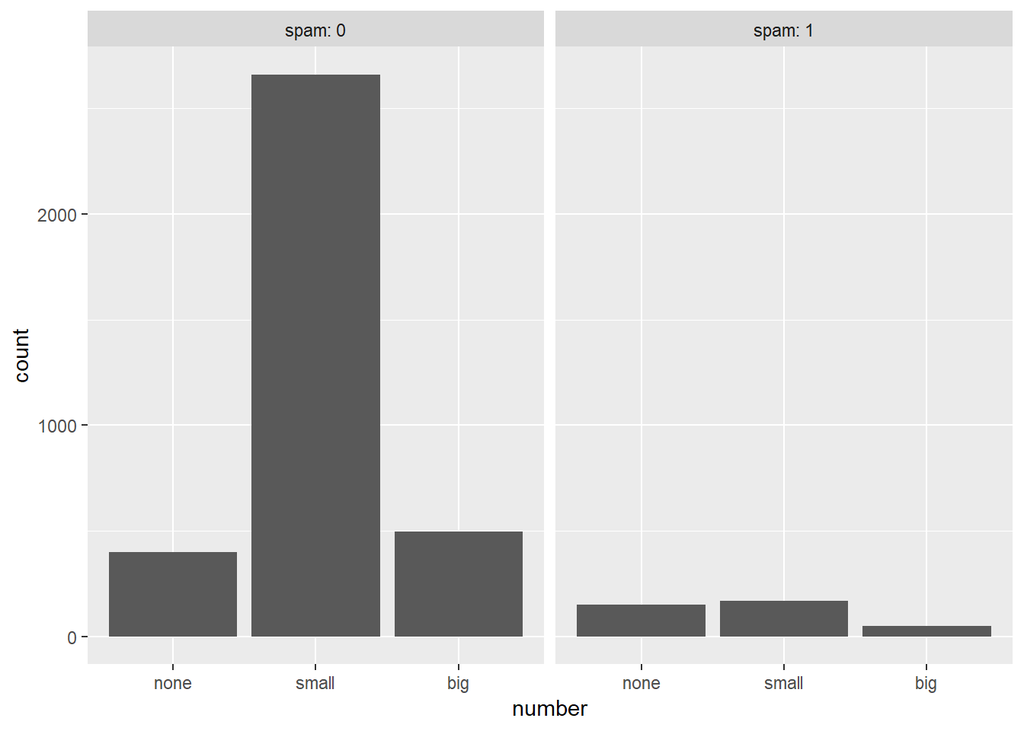

```r
# Reorder levels
email$number <- factor(email$number,
                       levels = c("none", "small", "big"))

# Construct plot of number
ggplot(email, aes(x = number)) +
  geom_bar() +
  facet_wrap(~spam, labeller = label_both)
```

What’s in a number interpretation Which of the following interpretations of the plot is not valid?

Possible Answers Given that an email contains a small number, it is more likely to be not-spam.

Given that an email contains no number, it is more likely to be spam. (Answer - more likely to be not-spam)

Given that an email contains a big number, it is more likely to be not-spam.

Within both spam and not-spam, the most common number is a small one.

# 3 Conclusion

## 3.1 Our goal

In this course on exploratory data analysis

- our goal is to get you comfortable exploring new dataset and provide a sense of considerations and techniques needed to find the most important structure in your data

## 3.2 Piechart vs Bar charts

- we started with categorical data, often the domain of the piechart and hopefully convinced that barcharts are a useful tool in finding associations between variables in comparing levels to one another

## 3.3 Faceting vs. Stacking

- we saw how the story can change depending on whethe we’re visualizing counts or proportions
- from there we moved on to numerical data
- and a collection of graphical techniques that are important the histogram, the density plot, and the box plot
- each has it’s strengths and weaknesses
- and in the third chapter we discuss the common numerical measures of a distribution
- measures of center(mean median mode),
- measures of variablity (IQR, sd),
- measures of shape (density plot - left, right skew, uniform, modal, bimodal, multimodal)
- plus presense of outliers (boxplot)
- use of combination of group_by and summarize to compute statistics on different subsets of data